# Analysis of genetic polymorphisms from the 1000 Genomes project from different human populations

Víctor Adell i Miquel Escobar

## Introducció

L’objectiu d’aquesta pràctica és classificar els polimorfismes genètics de la nostra base de dades en tres classes, corresponents a tres poblacions diferents. Les dades provenen de la seqüenciació del genoma d’una gran escala de gent, que és útil per veure com estan distribuides pel planeta les diferents mutacions i variacions. El que busquem és, precisament, detectar aquestes variacions i mutacions pròpies de cadascuna de les poblacions per a poder classificar totes les observacions.

Per detectar similituds entre membres del mateix grup i les diferències entre membres de grups diferents, i poder procedir a classificar les observacions, utilitzarem les tècniques de classificació Anàlisi Discriminant Lineal i Clusterització. Abans d’aplicar aquests algorsimes per la classificació, però, haurem de realitzar una reducció de la dimensionalitat mitjançant l’ Anàlisi de Components Principals i l’ Escalament Multidimensional. Aquesta reducció de la dimensió de les observacions és necessària per una eficient implementació dels nostres classificadors, però cal procurar que una reducció tant gran com la realitzada per aquest *dataset* mantingui prou informació per realitzar un anàlisi i classificació acceptables.

## Descripció de la base de dades

La base de dades utilitzada per aquest projecte prové del [National Human Genome Research Institute](https://www.genome.gov/), i pertanyen al [**1000 Genomes Project**](http://www.internationalgenome.org/). Aquest projecte busca mesurar les diferències genètiques per ajudar a la recerca mèdica a entendre la relació entre la variació genètica i les malalties. L’objectiu és construir un mapa de la variació genètica humana, amb una representació mínima de l’$1\%$ de cada població humana.

El contingut de la base de dades d’aquest projecte són polimorfismes genètics pertanyents a $389$ persones de tres poblacions diferents:

| Population sample | Population Size | Origin |
| --- | --- | --- |
| **ASW** | 87 | African ancestry in Southwest USA |
| **CEU** | 165 | Utah residents with Northern and Western European ancestry from the *CEPH collection* |
| **CHB** | 137 | Han Chinese in Beijing, China |

*A grosso modo*, cada persona té $46$ cromosomes, $23$ provinents del pare i $23$ de la mare i cada cromosoma està dividit en gens.

Un polimorfisme de nucleòtid simple (o SNP) és una variant d’un gen en un nucleòtid en concret que es dona en més de l’$1\%$ de la població. Si es rebaixa aquest mínim de l’$1\%$ deixaria de tractar-se d’un SNP per passar a considerar-se una mutació.

En la nostra base de dades s’analitzen $27,182$ SNP bi-al·lèlics (és a dir, que contenen o bé el nucleòtid *més habitual* o bé l’*estrany*). Per tant les tres possibles combinacions de cada SNP en la nostra base de dades són: AA (representat amb un 0), AB (representat amb un 1), BB (representat amb un 2). Cada grup poblacional té les seves variacions més característiques, pel que dues seqüències semblants formen part de la mateixa població i dues de molt diferents no.

A tall d’exemple, a mostrem els deu primers SNP’s dels deu primers individus de la base de dades, tots ells del grup ASW:

```r
load("data/DataFinal.RData")
Y[1:10,1:10]
```

|  | rs9442373_C | rs1571150_A | rs4074196_C | rs2748986_G | rs28508199_G | rs6661597_T | rs2257182_C | rs12045693_A | rs2843142_A | rs2840528_A |
| --- | --- | --- | --- | --- | --- | --- | --- | --- | --- | --- |
| NA19919 | 0 | 2 | 0 | 1 | 1 | 1 | 0 | 0 | 1 | 1 |
| NA19916 | 0 | 0 | 0 | 2 | 2 | 0 | 2 | 2 | 0 | 0 |
| NA19835 | 1 | 2 | 1 | 1 | 2 | 0 | 2 | 2 | 1 | 1 |
| NA20282 | 1 | 0 | 1 | 0 | 1 | 0 | 1 | 0 | 1 | 1 |
| NA19703 | 0 | 2 | 2 | 1 | 2 | 0 | 2 | 1 | 0 | 0 |
| NA19902 | 1 | 1 | 1 | 0 | 1 | 1 | 1 | 0 | 0 | 0 |
| NA19901 | 1 | 2 | 1 | 1 | 1 | 0 | 2 | 0 | 1 | 0 |
| NA19908 | 1 | 1 | 1 | 1 | 0 | 1 | 1 | 1 | 2 | 2 |
| NA19914 | 0 | 0 | 0 | 2 | 2 | 0 | 0 | 0 | 0 | 1 |
| NA20287 | 0 | 1 | 1 | 1 | 2 | 0 | 2 | 2 | 0 | 0 |

Per tenir una primera intuïció de com es distribueixen les dades, pels deu primers SNP’s en concret visualitzem quin percentatge de cada població té l’al·lel AA (valor 0 en les nostres dades):

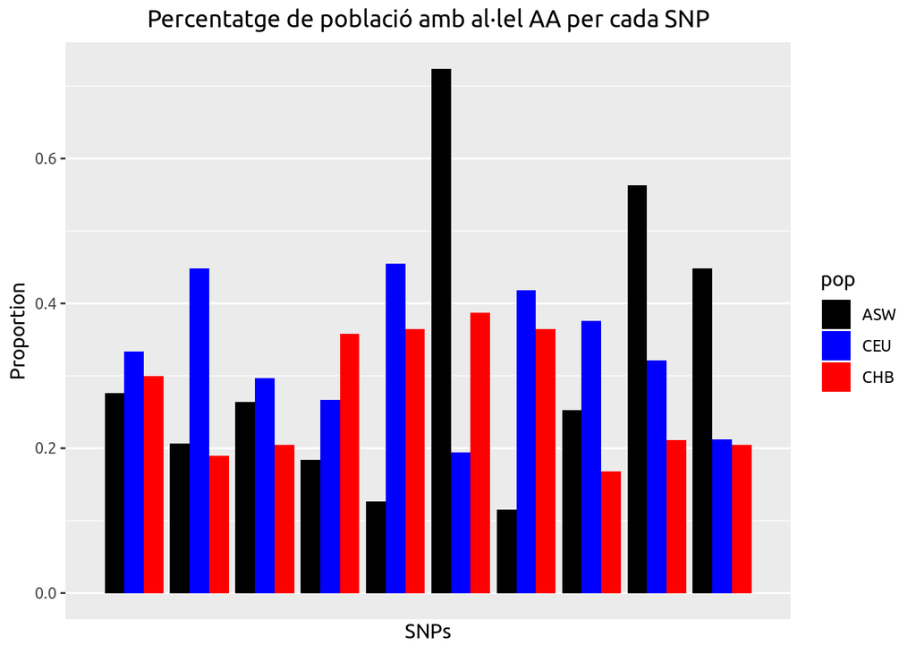

```r
library(ggplot2)
library(gridExtra)

N <- 10
MyPalette <- c(ASW = "black", CEU = "blue", CHB = "red")

prop <- function(row){
  table <- table(Y[population == row['pop'], as.numeric(row['SNPs'])])
  return(table[1] / sum(table))
}

SNPs <- c()
for (i in 1:N) SNPs <- c(SNPs, rep(i,3))
pop <- c()
for (i in 1:N) pop <- c(pop, c(levels(population)))

distr <- cbind.data.frame(SNPs, pop)
distr['Proportion'] <- apply(distr, MARGIN=1, FUN=prop)

g0 <- ggplot(distr, aes(fill=pop, y=Proportion, x=SNPs))
g0 + geom_bar(position="dodge", stat="identity") + scale_fill_manual(values = MyPalette) +
     scale_x_discrete(labels=c("1","2","3","4","5","6","7","8","9","10")) +
     labs(title="Percentatge de població amb al·lel AA per cada SNP") +
     theme(plot.title = element_text(hjust = 0.5)) + theme(text=element_text(family="Ubuntu"))
```

## Descripció i resultats dels mètodes emprats per l’anàlisi

En les pestanyes a continuació està cadascun dels mètodes desenvolupat per separat.

### PCA - Anàlisi de components principals

L’anàlisi de components principals (PCA) és un mètode emprat per reduir la dimensionalitat d’un conjunt de dades. El mètode consisteix, intuïtivament, en trobar uns nous eixos (d’ordenades i coordenades) que conté la major “informació” possible de les observacions. En altres paraules, troba la representació, en forma de combinació lineal, que concentra la major variància possible en cadascuna de les dimensions. És a dir, l’eix corresponent a la transformació lineal de la primera dimensió és el que captura més variància; els corresponents a la segona dimensió, són el primer eix i l’eix que més variància captura conjuntament amb el primer, i així successivament.

D’aquesta forma podrem reduir les $27182$ dimensions de les nostres observacions a un nombre molt més reduït, el que ens permetrà no només un tractament molt més senzill de les dades, sinó que també poder representar-les gràficament i visualitzar-les. En el nostre dataset, però, ens trobem amb què el nombre de mostres $n=389$ és més petit que el nombre de dimensions $p=27182$. Per tant, les dimensions màximes que poden prendre les dades transformades a PCA són $p_{max}=n$, ja que no existex cap conjunt d’eixos de $n+1$ dimensions en què tots continguin una variància de les dades superior a $0$. Per a poder realitzar el PCA en aquestes condicions esmentades, la funció per defecte de R `princomp` no és compatible, motiu pel qual utilitzarem la funció `PCA` de la llibreria [FactoMineR](http://factominer.free.fr/):

```r
# No utilitzar princomp, error degut a p > n

# Amb FactoMineR
library("FactoMineR")
res.pca <- PCA(Y, scale.unit=TRUE, ncp=5, graph=FALSE)
X <- res.pca$ind$coord[,1:2]
```

Analitzem la variància explicada per cadascuna de les dimensions, mitjançant un *Scree Plot*, per decidir quantes són suficients per procedir amb l’anàlisi:

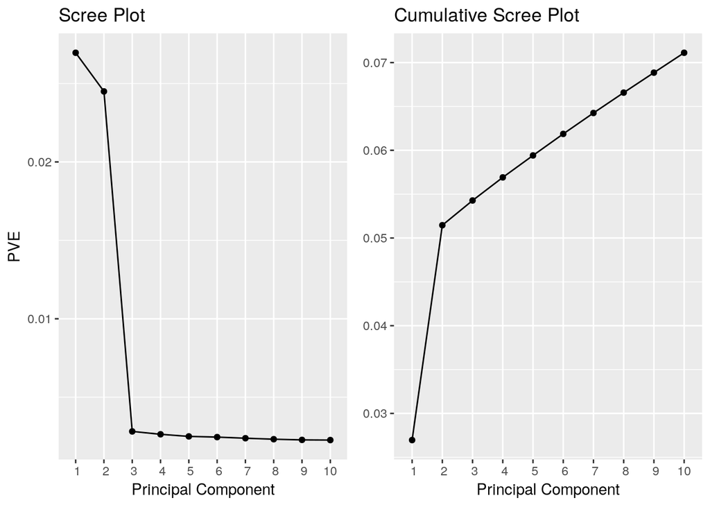

```r
PVE <- res.pca$eig / sum(res.pca$eig)
x <- c(1:10)
PVE <- PVE[x]

# PVE (aka scree) plot
PVEplot <- qplot(x, PVE) + geom_line() + scale_x_discrete(name ="Principal Component", limits=x) +
                           ylab("PVE") + ggtitle("Scree Plot")

# Cumulative PVE plot
cumPVE <- qplot(x, cumsum(PVE)) + geom_line() + scale_x_discrete(name ="Principal Component", limits=x) +
                                  ylab(NULL) + ggtitle("Cumulative Scree Plot")

grid.arrange(PVEplot, cumPVE, ncol = 2)
```

Mitjançant l’*Scree Plot*, podem concloure que el més adequat és quedar-nos amb $dues$ dimensions, que expliquen un $5.15\%$ de la variabilitat de les nostres dades. Per comprovar que les dues dimensions són suficients, visualitzem les dades transformades als dos primers components principals:

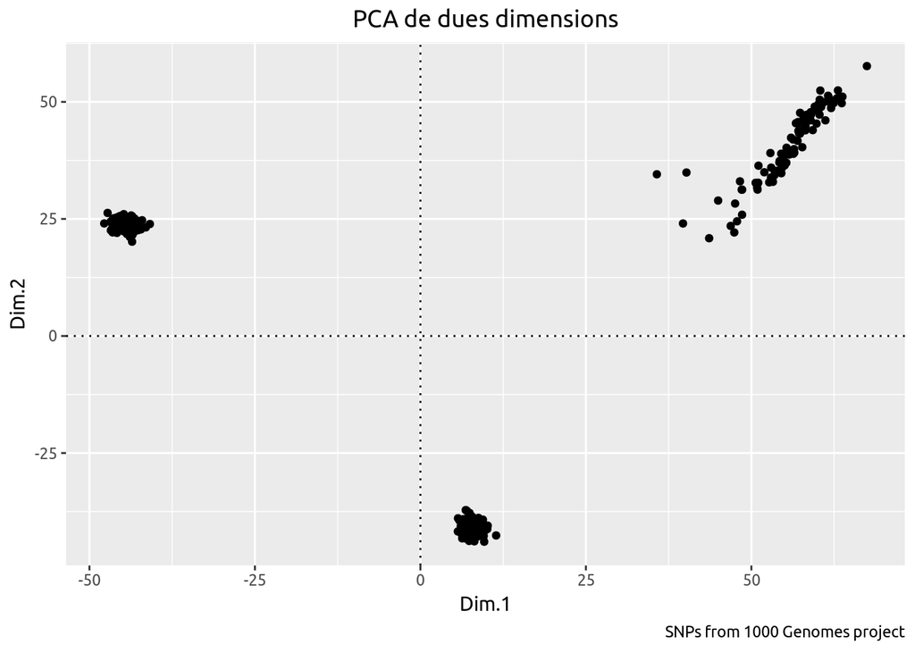

```r
X.df <- as.data.frame(X)
g <- ggplot(X.df, aes(x=Dim.1, y=Dim.2)) + geom_point()
g + geom_vline(xintercept=0, linetype="dotted") + geom_hline(yintercept=0, linetype="dotted") +
               labs(title="PCA de dues dimensions", caption="SNPs from 1000 Genomes project") +
               theme(plot.title = element_text(hjust = 0.5)) + theme(text=element_text(family="Ubuntu"))
```

Sembla que amb els dos primers components trobem una divisió molt clara entre tres grups. Donat que la mostra de dades conté els polimorfismes genètics corresponents a tres poblacions diferents, sembla que ens les ha diferenciat i que les dues dimensions són suficients per una correcta classificació de totes les observacions. Per a comprovar-ho, assignem un color per les observacions de cada grup:

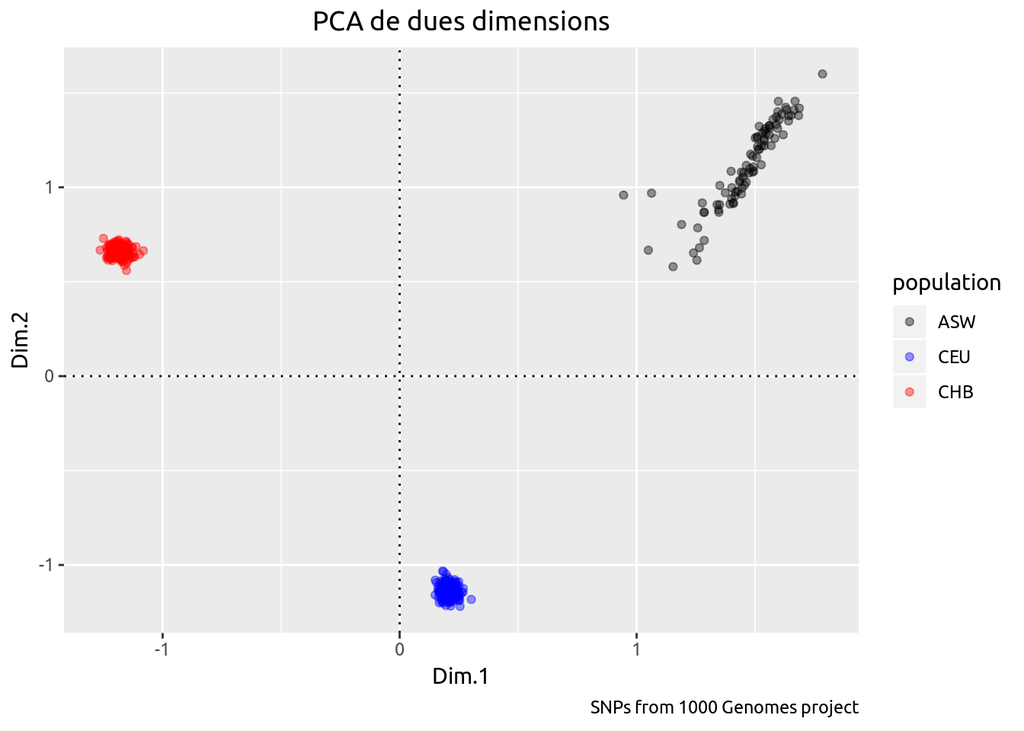

```r
X.s <- as.data.frame(scale(X))
X.s$population <- population

g2 <- ggplot(X.s, aes(x=Dim.1, y=Dim.2, color=population)) + geom_point(alpha=.4)
g2 + geom_vline(xintercept=0, linetype="dotted") + geom_hline(yintercept=0, linetype="dotted") +
               labs(title="PCA de dues dimensions", caption="SNPs from 1000 Genomes project") +
               theme(plot.title = element_text(hjust = 0.5)) + theme(text=element_text(family="Ubuntu")) +
               scale_colour_manual(values = MyPalette)
```

Efectivament, els dos primers components principals contenen prou informació sobre les dades com per poder diferenciar els tres grups poblacionals sense errors.

### MDS - Escalament Multidimensional

L’escalament multidimensional o MDS és també un mètode per a reduir la dimensió de les dades. A diferència de l’anàlisi de components principals, però, es basa en calcular distàncies entre les observacions, per poder generar una nova configuració dels punts en una dimensió més baixa (que s’acostumar a anomenar **map**). El plantejament per tant ha d’incloure un criteri per al càlcul de les distàncies (o bé similituds) entre dues observacions, en la què es basarà la generació del **map**. Una mesura de la distància $\delta()$ ha de satisfer:
$$\delta(A,B) = \delta(B,A) \\
\delta(A,B) \geq 0 \\
\delta(A,A) = 0$$
Es considera una mesura de distància **mètrica** si a més a més compleix:
$$\delta(A,B) = 0 \iff A=B \\
\delta(A,B) \leq \delta(A,C) + \delta(C,B)$$
Les mesures de distància mètriques més habituals són l’**euclidiana** i la **mahalanobis**. Ara bé, a l’hora de tractar amb dades genètiques, hi ha molta literatura que proposa diferents distàncies *ad-hoc*. Prendrem la **allele sharing distance** que ha estat discutida en el l’àmbit dels SNP en l’article de [*Using Allele Sharing Distance for Detecting Human Population Stratification*](https://www.ncbi.nlm.nih.gov/pmc/articles/PMC2869072/#B22).

Es basa en considerar $x_{ijk}$ el nombre d’alels comuns entre l’individu $i$ i $j$ per la variant $k$:

$$d_{ij} = \frac{1}{K} \sum_{k=1}^{K}{d_{ijk}}\ ,\ \ \text{amb}\ d_{ijk} = 2 - x_{ijk}$$
Per tant, la distància $d_{ij}$ és equivalent a:

| i/j | AA | AB | BB |
| --- | --- | --- | --- |
| **AA** | 0 | 1 | 2 |
| **AB** | 1 | 0 | 1 |
| **BB** | 2 | 1 | 0 |

D’aquesta forma, la matriu $\mathbf{D} = [d_{ij}]$ s’utilitza com a **input** per l’escalament multidimensional. Per tal de construir-la hem programat el següent codi en `C++` per raons d’eficiència:

```
#include <Rcpp.h>

using namespace Rcpp;

// [[Rcpp::export]]
NumericMatrix allele_distance(NumericMatrix x) {
    int n = x.nrow();
    int k = x.ncol();
    NumericMatrix d = no_init_matrix(n, n);

    for (int i = 0; i < n; ++i) {
        for (int j = i + 1; j < n; ++j) {
            d(i, j) = sum(abs(x(i,_) - x(j,_)))/k;
            d(j, i) = d(i, j);
        }
        d(i, i) = 0;
    }

    return d;
}
```

En resulta la matriu $\mathbf{D}$ següent:

```r
# library(Rcpp)
# sourceCpp("bin/allele_distance.cc")
# matriu D calculada i carregada des de DataFinal.RData degut al cost d'execució
# D <- allele_distance(as.matrix(Y))
D[1:5, 1:5]
```

```
##           [,1]      [,2]      [,3]      [,4]      [,5]
## [1,] 0.0000000 0.6751527 0.6846075 0.6895004 0.6752998
## [2,] 0.6751527 0.0000000 0.6743065 0.6883232 0.6724303
## [3,] 0.6846075 0.6743065 0.0000000 0.6901994 0.6845339
## [4,] 0.6895004 0.6883232 0.6901994 0.0000000 0.6917077
## [5,] 0.6752998 0.6724303 0.6845339 0.6917077 0.0000000
```

En visualitzar la matriu de distàncies ja podem percebre la clara distinció entre els tres grups de poblacions presents a l’estudi:

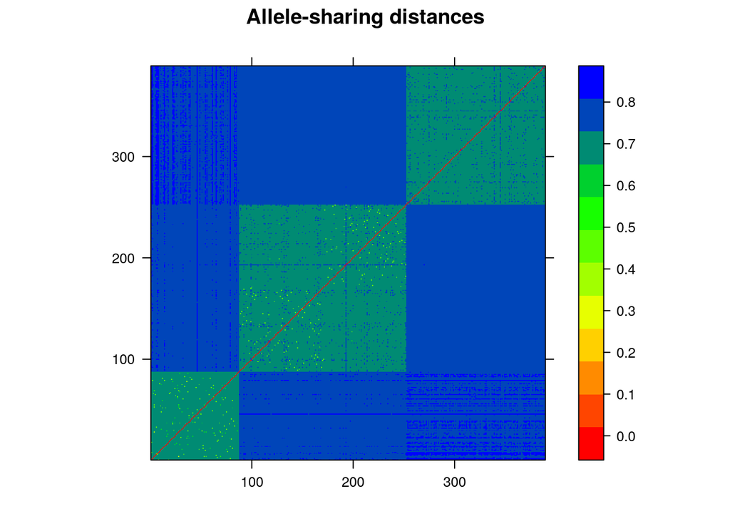

```r
library(lattice)
levelplot(D, col.regions=colorRampPalette(c("red", "yellow", "green", "blue")), cuts=11,
          main="Allele-sharing distances", xlab="", ylab="")
```

Generem i visualitzem el MDS en dues dimensions de la nostra matriu $\mathbf{D}$:

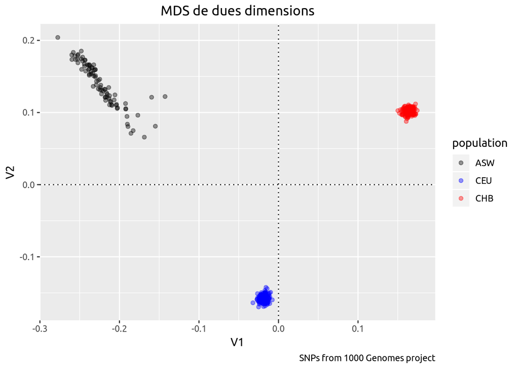

```r
loc <- cmdscale(D)
loc.df <- as.data.frame(loc)
distmds <- as.matrix(dist(loc))

g3 <- ggplot(loc.df, aes(x=V1, y=V2, color=population)) + geom_point(alpha=.4)
g3 + geom_vline(xintercept=0, linetype="dotted") + geom_hline(yintercept=0, linetype="dotted") +
               labs(title="MDS de dues dimensions", caption="SNPs from 1000 Genomes project") +
               theme(plot.title = element_text(hjust = 0.5)) + theme(text=element_text(family="Ubuntu")) +
               scale_colour_manual(values = MyPalette)
```

Per a mesurar la qualitat del nostre model i la informació captada, podem calcular la proporció de variabilitat explicada per l’MDS mitjançant:

$$\frac{\lambda_1+\lambda_2}{\sum_{i=0}^{p}{\lambda_i}}$$

```r
eig <- cmdscale(D, eig=T)$eig
(eig[1]+eig[2])/sum(abs(eig))
```

```
## [1] 0.1358159
```

Obtenim un $13,58\%$. Aquest percentatge sembla millor que en el cas del PCA, tot i així els gràfics semblen pràcticament idèntics i la separació dels tres grups és la mateixa.

Observem les distàncies reals respecte la transformació de la distància corresponent al **map** generat per l’MDS en dues dimensions:

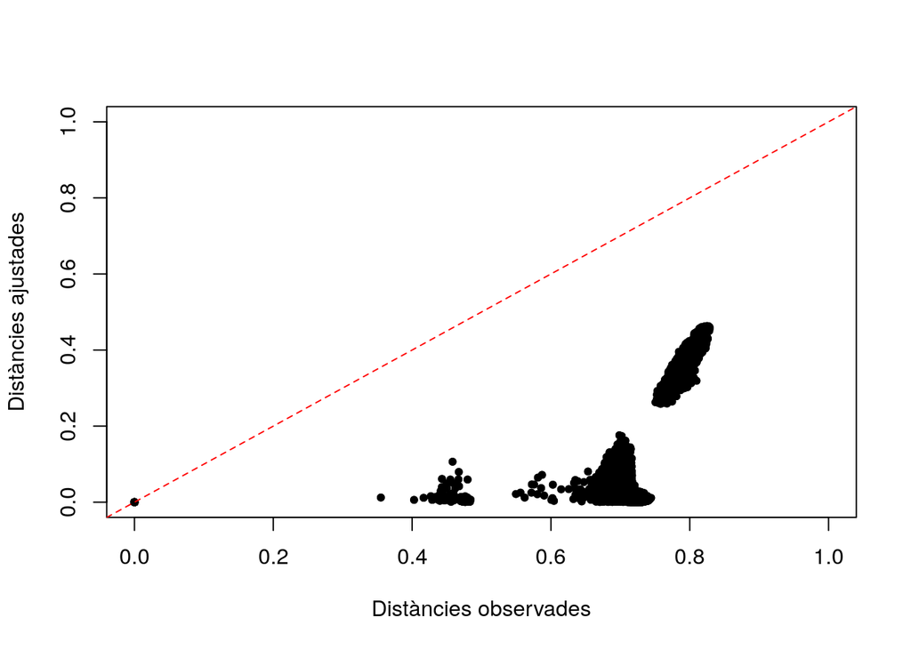

```r
plot(x=D, y=distmds, pch=20, xlab="Distàncies observades", ylab="Distàncies ajustades",
     xlim=c(0,1),ylim=c(0,1))
abline(a=0,b=1, col='red', lt=2)
```

Sembla que totes les distàncies són més petites en el **map** de dues dimensions que en els punts de dimensió $p=27182$.

### LDA - Anàlisi Discriminant Lineal

L’Ànalisi Discriminant Lineal o LDA és un mètode estadístic que busca combinacions lineals de trets que caracteritzen i separen dues o més classes per a poder realitzar classificacions. El mètode es basa en reduir al màxim la probabilitat de classificar incorrectament les observacions tenint en consideració una funció de cost. En un cas en què volguem diferenciar dos grups ($R_1$ i $R_2$), per exemple, la probabilitat d’una classificació ($\pi_1$ o $\pi_2$) errònea és la següent:
$$P(X \in R_2\ |\ \pi_1) = \int_{R_2}{f_1(x)dx} \\
P(X \in R_1\ |\ \pi_2) = \int_{R_1}{f_2(x)dx}$$

Així doncs, en el nostre cas tenim tres grups ($R_{ASW}$, $R_{CEU}$ i $R_{CHB}$), i busquem un model que ens retorni la probabilitat de que cada punt pertanyi a cada grup.

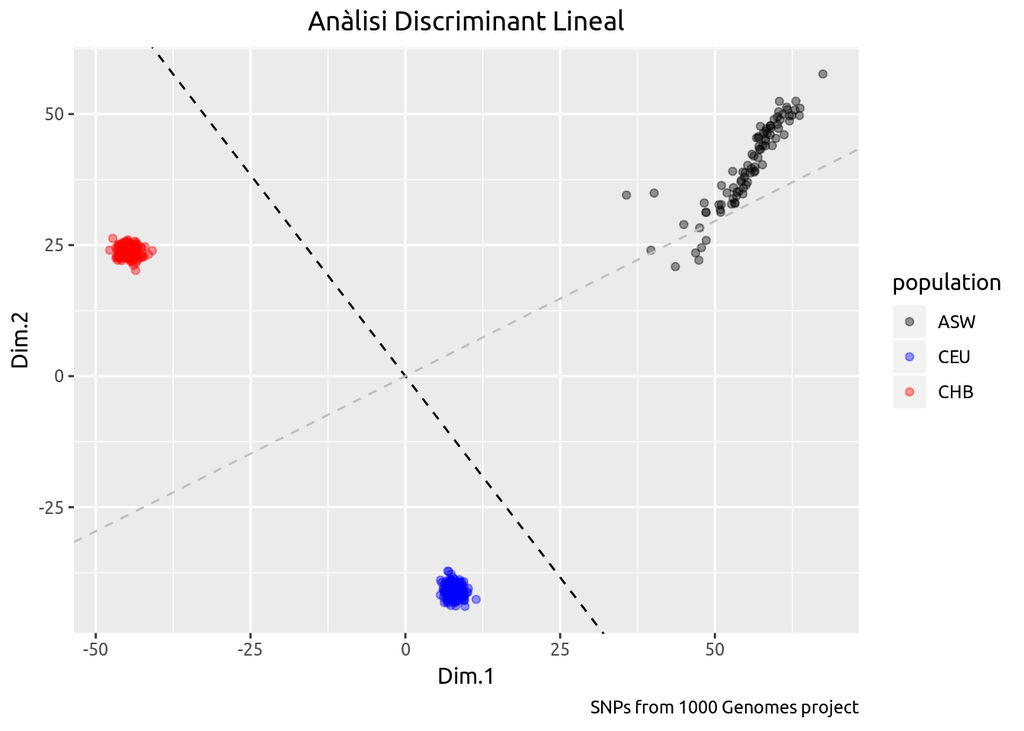

```r
library(MASS)
res.lda <- lda(X, grouping=population)

b1 <- res.lda$scaling[1,1]/res.lda$scaling[2,1]
b2 <- res.lda$scaling[1,2]/res.lda$scaling[2,2]

g5 <- ggplot(X.df, aes(x=Dim.1, y=Dim.2, color=population)) + geom_point(alpha=.4)
g5 + geom_abline(intercept=0, slope=b1, linetype='dashed') +
     geom_abline(intercept=0, slope=b2, linetype='dashed', col='gray') +
     labs(title="Anàlisi Discriminant Lineal", caption="SNPs from 1000 Genomes project") +
     theme(plot.title = element_text(hjust = 0.5)) + theme(text=element_text(family="Ubuntu")) +
     scale_colour_manual(values = MyPalette)
```

Vegem ara, per confirmar-ho, la taula de confusió entre les prediccions del nostre model LDA i els valors reals:

```r
pred <- predict(res.lda, X)$class
(confTable <- table(Truth=population, Predicted=pred))
```

```
##      Predicted
## Truth ASW CEU CHB
##   ASW  87   0   0
##   CEU   0 165   0
##   CHB   0   0 137
```

No hi ha cap error en la classificació, per tant la mesura d’error $APER$ del nostre model
$$APER = \frac{ \sum_{i=1}^{3}{\sum_{j=1}^{3}{n_{ij}\ (i\neq j)}}}{\sum_{i=1}^{3}{n_i}}$$
valdrà $0\%$:

```r
library(scales)
confM <- as.matrix(confTable)
(aper.lda <- (sum(confM)-sum(diag(confM)))/sum(confM))
```

```
## [1] 0
```

Efectivament, tenim un $APER=0.0\%$.

### Clusterització

La Clusterització de dades o Clustering és una tècnica per a la classificació d’observacions similars en diferents grups, és a dir, la partició de dades en subconjunts. Considerarem dos tipus d’algorismes: els jeràrquics i els particionals.

#### Clustering jeràrquic

Es generen nous clústers a mesura dels ja existents en el corresponent pas de l’algorisme. En l’inici, cada punt o observació es considera un clúster diferent. Per decidir el nou clúster que es forma, existeixen múltiples criteris, com per exemple la unió dels dos clústers amb mitjanes més properes. En aquest cas, utilitzarem el criteri de **Ward**: donats dos clústers $r$ i $s$, la seva unió genera un nou clúster $t$; els dos clústers seleccionats són aquells dos amb $\Delta_t$ mínima, on:

$$\Delta_t = WSS_t - (WSS_r+WSS_s) = \frac{n_rn_s}{n_r+n_s}d^2_{rs} \\
\text{amb}\ WSS_z = \sum_{j=1}^{p}{\sum_{i=1}^{n_z}{(x_{ij}-\hat x_j)^2}}$$

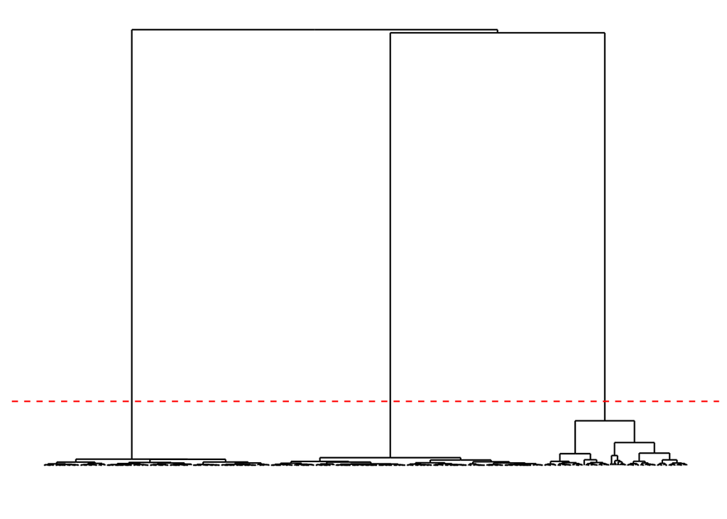

```r
library(ggdendro)

D <- dist(X.s)
hc.ward <- hclust(D, method="ward.D2")
ggdendrogram(hc.ward) + theme(axis.text.x=element_blank(), axis.text.y=element_blank()) +
                        geom_hline(yintercept=5, linetype='dashed', color='red')
```

Basant-nos en el dendrograma, el tall en el clústering jeràrquic s’ha de realitzar per $k=3$, que es correspon al nombre de grups poblacionals de les nostres dades.

```r
cutClust <- cutree(hc.ward, 3)

cutClust[cutClust==1] = "ASW"
cutClust[cutClust==2] = "CEU"
cutClust[cutClust==3] = "CHB"

table(Truth=population, Predicted=cutClust)
```

```
##      Predicted
## Truth ASW CEU CHB
##   ASW  87   0   0
##   CEU   0 165   0
##   CHB   0   0 137
```

El clústering jeràrquic realitzat, amb el criteri de **Ward**, també ens classifica totes les observacions correctament.

#### Clustering particional

L’algorisme que emprarem pel clustering particional, $k$-means, és el següent:

1. Es seleccionen $k$ centroides (de forma aleatòria), cadascun representant de cada grup.
2. Cada punt s’assigna al grup del qual el seu centroide és més proper.
3. Els nous centroides es calculen com la mitjana de tots els punts que pertanyen al grup.
4. Es torna al punt 2, i es repeteix fins que ja no hi ha canvis.

L’algorisme visualitzat és així:

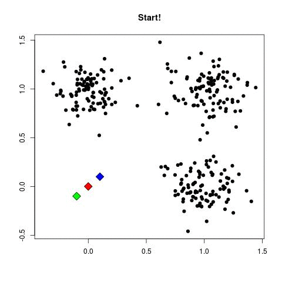

Aplicant el $k$-means amb $k=3$ (ja que tenim tres grups poblacionals), obtenim el següent model:

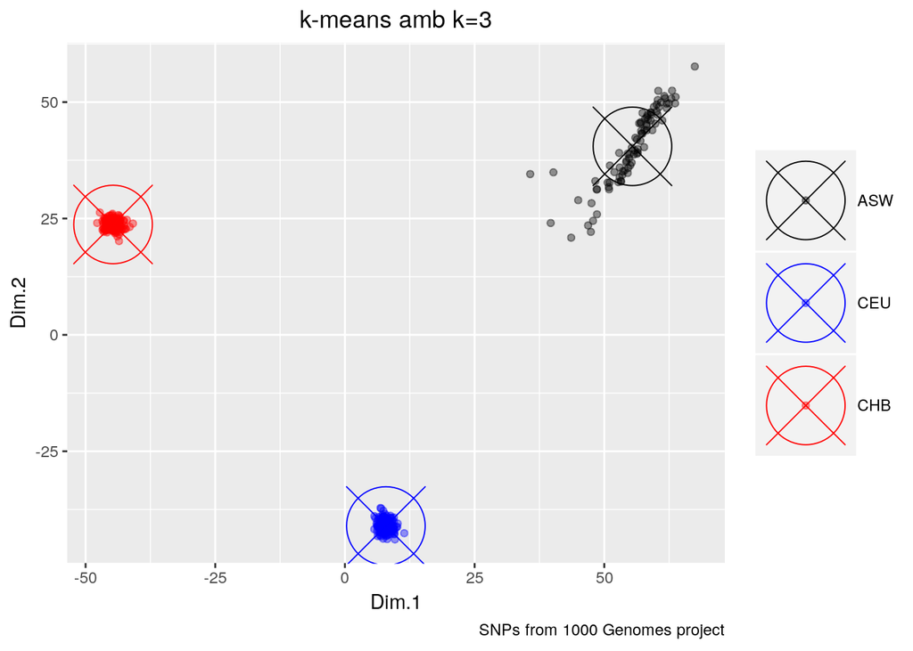

```r
set.seed(2)

n_clusters <- 3
X.km <- X
Xcluster <- kmeans(X.km, n_clusters)
X.km <- cbind.data.frame(X.km, Xcluster$cluster)
colnames(X.km) <- c(colnames(X.km)[c(1,2)], 'cluster')

X.km$cluster[X.km$cluster==1] = "ASW"
X.km$cluster[X.km$cluster==2] = "CHB"
X.km$cluster[X.km$cluster==3] = "CEU"
X.km$cluster = as.factor(X.km$cluster)


centroids <- data.frame(cluster = factor(c("ASW","CHB","CEU")),
                        Dim.1 = Xcluster$centers[,1],
                        Dim.2 = Xcluster$centers[,2])

g6 <- ggplot() + labs(title="k-means amb k=3", caption="SNPs from 1000 Genomes project") +
     theme(plot.title = element_text(hjust = 0.5)) +
     geom_point(data = centroids, mapping = aes(x=Dim.1, y=Dim.2, color=cluster), size=20, pch=13) +
     geom_point(data = X.km, aes(x=Dim.1, y=Dim.2, color=cluster), alpha=.4) +
     scale_colour_manual(values = MyPalette) + theme(legend.title = element_blank())

g6
```

Com era d’esperar, el clústering mitjançant l’algorisme $k$-means també diferencia els tres grups sense errors i per tant classifica correctament totes les observacions.

## Conclusions i discussió

Les conclusions que podem treure de l’anàlisi i les classificacions dels nostres models és que les seqüències genètiques contenen prou informació com per separar les tres poblacions de la mostra sense errors. Cal tenir en compte que els models els hem basat en les dades transformades per l’Anàlisi de Components Principals, és a dir, que de les $p=27182$ dimensions inicials ens hem quedat amb dues, que expliquen poc més del $5\%$ de la variabilitat total i tot i així, les tècniques de classificació no han comès ni un sol error en la classificació de les $389$ persones. Destaquem, doncs, la importància de realitzar la reducció de dimensionalitat amb aquest tipus de dades, mitjançant o bé l’Anàlisi de Components Principals o bé l’Escalament Multidimensional, ja que aquesta reducció ens permet generar i aplicar models a les dades amb un cost computacional increïblement inferior i amb una eficiència, en aquest cas, immillorable. Probablement, però, els tres grups poblacionals pertanyents a aquest *dataset* són grups amb diferències genètiques molt importants. Caldria veure si amb qualsevols poblacions es podria obtenir aquest encert del $100\%$ en les classificacions tot i aquesta dràstica reducció d’informació.

## Bibliografia

- [Single Nucleotide Polymorphism](https://en.wikipedia.org/wiki/Single-nucleotide_polymorphism)
- [National Human Genome Research Institute](https://www.genome.gov/)
- [1000 Genomes Project](http://www.internationalgenome.org/)
- [Using Allele Sharing Distance for Detecting Human Population Stratification](https://www.ncbi.nlm.nih.gov/pmc/articles/PMC2869072/#B22)
- [Population Structure and Eigenanalysis](https://www.ncbi.nlm.nih.gov/pmc/articles/PMC1713260/)